# The Impact of Non-tipping Business Model on Restaurants’ Operations and Financial Performance

Ningdan Zhang, Selina Sun, Rachel Dingzeng, Ethan Yin, Haijin Chen

# Research Design of Non-tipping Model

## Part 1: Research Proposal

### Executive Summary / Abstract

**Authors (Names and Percentages)**: Selina Sun 50%, Ethan Yin 50%

In the US, it is customary for customers to leave the service provider a gratuity—often referred to as a tip—in addition to the basic service charge as a way of showing their appreciation. Tipping enables Texas Roadhouse managers to reward employees, gauge server effectiveness, and pinpoint disgruntled patrons. Meanwhile, the tip credit system permits Texas Roadhouse to take a certain amount of tips as a credit against the minimum wage requirements established for the restaurant industry. However, a scandal involving a dispute with its own employees over the tip credit system has engulfed Texas Roadhouse. Moreover, when more and more foreign restaurants are introduced, customers start to realize the advantages and select eating settings where gratuities are not required. It reaches the point where Seattle’s city government has prohibited tips for eateries since 2017. Although prior studies have shown that Seattle’s Non-Tipping model has a favorable impact on the operations and profitability of the restaurant, there is no applicability for Texas Roadhouse Restaurants. Consequently, the purpose of this study is to investigate whether Texas Roadhouse restaurants are suitable for the Non-Tipping model.

The research began with cluster sampling. 30 samples will be chosen from a total of 300 Texas Roadhouse restaurants operating in the Conventional Tipping model across the United States for this study. The treatment group will implement a non-tipping (NT) model, in which restaurants abandon the customary tipping system in favor of raising menu prices and server salaries. The control group will use a conventional-tipping (CT) model, in which restaurants continue to operate as usual.

A survey will be done to assess employees’ intentions to work on a scale from 0 to 10, and data such as end-month profit and average number of customers received by restaurants will be gathered. To test the research’s hypothesis, two-sample t-tests will be utilized to compare the difference in the effect of treatments on dependent variables of interest. The process and result of the simulation in the second part can serve as a reference for future experiments.

### Statement of the Problem

**Authors (Names and Percentages)**: Ningdan Zhang 100%

A tip is a payment from customers given directly to the service providers. With President Joe Biden’s campaign on raising wages for low- and middle-class workers starting from April 2021, some restaurants are considering instituting no-tipping policies. That is, to eliminate tips and raise the prices at a certain scale so that the restaurant owners can redistribute more evenly to their workers and kitchen staff.

Although many countries in Asia, Australia, and Southern America do not have a tipping culture, it is hard to imagine not leaving tips before walking out of any service business in this highly pro-tipping US. Since tipping is considered a highly recognized and well-accustomed habit in this country, it is a relatively hard step to implement the no-tipping business model due to its to-be-unveiled consequences and impact.

This study will help provide evidence to service businesses in the US, specifically Texas Roadhouse managers using conventional tipping models in their restaurants, regarding how their revenues can be influenced by the no-tipping method, displaying an insight into whether to take action on implementing the no-tipping model in their business.

### Research Questions and Hypotheses

**Authors (Names and Percentages)**: Selina Sun 100%

Since changing tipping models would significantly impact the restaurant operations and financial performance measurements, the present study aims at answering the following questions and testing listed hypotheses.

#### Profit

*Do non-tipping models increase restaurant profit?*

**Null Hypothesis**: Average profit generated from Non-tipping(NT) model is less or equal to average profit generated from Conventional-tipping(CT) model

**Alternative Hypothesis**: Average profit generated from NT model is greater than average profit generated from CT model

- $H_0$: $μ_{NT}$ - $μ_{CT}$ ≤ 0
- $H_a$: $μ_{NT}$ - $μ_{CT}$ > 0

#### Customer Flow

*Do non-tipping models increase customer flow?*

**Null Hypothesis**: Average monthly number of customers in NT model is less or equal to Average monthly number of customers in CT model

**Alternative Hypothesis**: Average monthly number of customers in NT model is greater than Average monthly number of customers in CT model

- $H_0$: $μ_{NT}$ - $μ_{CT}$ ≤ 0
- $H_a$: $μ_{NT}$ - $μ_{CT}$ > 0

#### Employees’ Intention to Work

*Do non-tipping models influence employees’ intention to work?*

**Null Hypothesis**: Mean employees rating score from NT model is same as mean employees rating score from CT model

**Alternative Hypothesis**: Mean employees rating score from NT model is different from mean employees rating score from CT model

- $H_0$: $μ_{NT}$ - $μ_{CT}$ = 0
- $H_a$: $μ_{NT}$ - $μ_{CT}$ ≠ 0

### Importance of the Study

**Authors (Names and Percentages)**: Rachel Dingzeng 100%

Prior studies have suggested whether restaurants should drop tipping, but this study presents a new Non-tipping model, and compares the performance of the Non-tipping (NT) model with the Conventional-tipping (CT) model in terms of restaurant profits, customer traffic, and employee satisfaction in more detail. Specifically, the study results would help Texas Roadhouse to better understand how Non-tipping (NT) model and Conventional-tipping (CT) model work differences in influencing their operations in three aspects: profit of the restaurant, customer flow, and employee satisfaction.

Moreover, the casual-dining restaurant chain is one of the most common restaurant types in the United States, which would also be beneficial from our proposed changes and research results. The research results can be used as a guide to casual-dining restaurants to understand the different impacts between the NT and CT on the restaurant’s profit, customer flow, and employees’ intention to work. The study result would also be able to serve as a foundation for future research that aims to examine other facets of the tipping model in the United States.

### Literature Review

**Authors (Names and Percentages)**: Rachel Dingzeng 100%

### Research Plan

#### *Population of Interest*

**Authors (Names and Percentages)**: Ethan Yin 100%

The study collaborates with Texas Roadhouse, an American cuisine steak restaurant, which has expanded its business internationally. However, since this research study only focuses on the domain of the United State, the population is narrowed to 611 locations across the United States. Texas Roadhouse restaurants typically have three currently predominant tipping policies: base salary plus self-collected tips (Conventional Tipping Model), base salary plus shared tip, and base salary plus sales promotion. Since the study only concentrates on the comparison between CT model and NT model, the population of interest is 300 restaurants currently using the Conventional Tipping Model–base salary plus self-collected tips.

#### *Sample Selection*

**Authors (Names and Percentages)**: Rachel Dingzeng 100%

The sample selection would be selected from these 300 Texas Roadhouses in the United States according to the population of interests. We’ll utilize cluster sampling to ensure that the sample is essentially representative of the population. The sample would be chosen via cluster sampling from naturally occurring groupings. Counties would be employed as clusters in this research. The rationale is that counties in the United States occupy a smaller geographic area than states and a larger area than cities. Therefore, the number of Texas Roadhouses would have a reasonable distribution in different counties. At the same time, people in the county tend to have similar consumption habits, dietary preferences, and tipping habits.

We would first filter out counties without a Texas Roadhouse and count the number of counties that have a Texas Roadhouse as part of the precise sample selection process. Second, we would select clusters using simple random sampling. Lastly, samples for the study would be selected by simple random sampling from the chosen clusters.All the samples that have been chosen from the same cluster would be implementing the same model (a NT or a CT). This would minimize the possibility of error that people who live near more than one Texas Roadhouse may be confused by the different policies of two restaurants close to each other.

After the simulation, a suggested sample size would be provided to make the analysis reliable enough for addressing the research questions. Operational procedures go into further depth about how the distribution of control groups and treatment groups would be implemented.

#### *Operational Procedures*

**Authors (Names and Percentages)**: Haijin Chen 100%

Once the sample selection technique and the sample size are confirmed, all Texas Roadhouse restaurants in the sample would be randomly assigned to the non-tipping model or the conventional-tipping model. Conventional-tipping model is utilized by the control group where restaurants continue to operate as usual with the traditional tipping system in which customers tip waiters after paying the checks. The non-tipping model is employed by the treatment group where restaurants forgo the tipping collection but shift to the increase in menu prices by 18% and the increase in waiters’ salaries through a defined algorithm due to non-tipping. At restaurants in the treatment group, customers would be displayed the announcement along with the menu that the restaurant would stop charging tips, to ensure that the customers are clearly informed before placing orders. All restaurants in the sample should start the experiment on the tipping or non-tipping model at the same time of the year, and the experiment would last for one month. At the end of the experiment, data on monthly revenues, monthly profits, customer flows, and a survey of service personnel with the question ‘I have the intention to work with the current tipping policy’ would be collected and analyzed for all restaurants in the sample.

In the experiment, it is assumed that customers generally choose an 18% tip, so when the non-tipping model is applied in action, the price of the menu would also increase by 18%. Customers’ purchasing power would remain at the same level, and what has changed is how customers would order based on their perceptions of non-tipping and increased menu prices. Waiters would no longer receive tips, but their salary composition has changed from base salary plus the bonus that is calculated by an algorithm. The algorithm would record the difference between the total price of the new menu price and that of the old menu price for each order (18% difference), then add it to the bonus for the waiter who provided service for this order. The salaries of waiters would still be maintained at the same level.

The length of the experimental period is considered for various factors. First, employees are paid monthly in most cases, and a short experimental period might have a bias on employees’ perceptions of intention to work. Secondly, the fixed costs of the restaurant, such as rent, are calculated on a monthly basis, and the one-month period reduces the complexity of measuring profits. At last, the one-month experiment is actionable.

#### *Brief Schedule*

**Authors (Names and Percentages)**: Ethan Yin 100%

The project will be completed in the following three phases, which will take roughly one month and two weeks:

- The Planning Phase (1 week):

In this phase, the empirical period will be designed. To make the result of the research more representative, national holidays and festivals should be avoided. Additionally, if possible, the study topic and survey might be revised to suit the practical need at this time.

- The Empirical Phase (1 month):

The empirical phase will start at the beginning of a month. The research process and data collection will last for a month, under the guideline of the operational procedures. A survey will be provided to employees at the end of the month.

- The Analytic and Dissemination Phase (1 week):

After all survey data is collected, the project moves to its final phase where statistical analysis will take place. Once data is analyzed, results will be interpreted to determine the meaning and importance of the findings. To offer insights that can be put into practice, a research report will be created to include all significant findings and the study procedure at this phase.

#### *Data Collection*

**Authors (Names and Percentages)**: Ethan Yin 100%

Two previously discussed tippling strategies, the Non-Tipping(NT) model and the Conventional Tipping(CT) model, will be administered appropriately to each subject over a one-month period after treatment and control groups are chosen by cluster sampling strategy. Data collection will be done using programs like Excel and R. At the start of the empirical phase, independent variables like models (NT/CT) will be gathered. At the end of the empirical phase, dependent variables and other relevant variables like profit, customer flows, employee survey results, and employee salary will be gathered from each participant restaurant. The survey’s content is as follows: Instructions: We want to find out more about your paying and working experience. How much do you agree with the following sentence? Please rate each statement on a scale from 0 (least agreement) to 10 (most agreement).

Q1: I am satisfied with your current work.

Q2: I am satisfied with my current paycheck.

Q3: I am satisfied with the amount of tips I gain.

Q4: In comparison to last month, my payroll has increased.

Q5: I am satisfied with the restaurant’s tipping policy.

Q6: I have the intention to work with the current tipping policy.

Q7: Describe any further information you would like us to know regarding your thoughts on the non-tipping policy. (Free Response)

#### *Data Security*

**Authors (Names and Percentages)**: Selina Sun 100%

Since the Treatment group implements the Non-Tipping model, menu prices would remain the same among restaurants in the treatment group after the 18% increase. Meanwhile, to maintain the confidentiality and security of the records, all participating restaurants in the experiment strengthen the system security to avoid data leaks and to exclusively allow managers to adjust the price of the menu to accord with the segregation of duty principle. On the other hand, all waiters and employees are pre-notified and trained to accommodate the Non-Tipping model. All employees are prohibited from communicating about the tipping model and salary received between restaurants to avoid bias in the survey and measurement.

#### *Variables*

##### Outcomes (Dependent Variables):

**Authors (Names and Percentages)**: Selina Sun 100%

For this study, there are three dominant dependent variables measured — profit, number of customers, and employees’ survey rating about the intention to work. The primary purpose of this experiment is to figure out whether switching to the Non-Tipping(NT) model can benefit the Texas Roadhouse restaurant in several ways although the process may impact the restaurant operations and financial performance measurements.

For the profitability research question, the treatment group–restaurants with the NT model would first increase its menu price by 18% before the study started. Then, after the month of the experiment, both treatment and control groups will collect their revenue generated. Then, the number will be subtracted by costs which include but are not limited to operation cost, occupancy cost, food cost, and labor cost. The EBITDA index would be the number to measure and test. For the customer research question, both treatment and control groups will keep accurate and close records of the number of customers received by the restaurant daily. In addition, for the intention to work ratings, all waiters and waitresses participating in the study will be mandated to fill out the 10-score survey. One of the questions in the survey will measure the employee’s intention to work.

##### Treatments (Independent Variables):

**Authors (Names and Percentages)**: Rachel Dingzeng 100%

##### Other Variables:

**Authors (Names and Percentages)**: Ningdan Zhang 100%

Salary Changes: Besides the survey scores collected from employees, salary changes should also be needed for those employees who worked in the NT model such that the differences in number could illustrate the effect of the NT model on employees and employee performance and testify whether the increase of 18% in menu prices are valid.

### Statistical Analysis Plan

**Authors (Names and Percentages)**: Ethan Yin 100%

The aim of this project is trying to determine whether a Non-tipping(NT) model can affect the population of interest: if using the NT models model can generate more profit for Texas Roadhouse than using the Conventional-tipping(CT); if the NT model can increase more customer flow than CT models; and if the NT models will influence the employees’ intention to work. Based on the fact that all the questions are comparing the mean of two groups, using two-sample t-tests as the statistical analysis plan will be appropriate to answer the research question. The statistical analysis will take place in the Analytic and Dissemination Phase and analysts will use t-test to find whether the result is meaningful.

### Sample Size and Statistical Power

**Authors (Names and Percentages)**: Selina Sun 100%

For this experiment, after careful consideration of the cost control and the use of statistical methods, the sample size would be decided to be 30 Texas Roadhouse restaurants, which is 15 restaurants for each of the control and treatment groups. The following are the rationales for choosing this size. The study would generate more than one outcome, so the sample size would be selected based on the most highly prioritized research question which is related to profit. According to Texas Roadhouse’s financial statement in the fiscal year 2021, the company’s operating income for the year was $297,192,000 and it had approximately 600 restaurants nationwide, so the average monthly profit per restaurant was about $41,000. A 10% increase in profit to $41,000*110%=$45,100 for this experiment is expected to be large enough to be a meaningful effect size of the difference in means for Texas Roadhouse to make a decision. Since the standard deviation of profit for all restaurants is unknown, the range rule of thumb would be employed to predict this figure. 4,000 standard deviation is then adopted because a $16,000 range around mean profit is a reasonable estimation, and the standard deviation is about a quarter of the range by the rule.

Finally, whether to shift from a conventional model to a non-tipping model is a deliberation for Texas Roadhouse, so the power required is set at 0.85 which is higher than the usual level 0.8 to ensure that there would be more evidence to support the decision. The significance level would be set at a default value of 0.05.

```r
library(pwr)
tpower = pwr.t.test(d=(45100-41000)/4000,sig.level=0.05,alternative='greater',power=0.85)
tpower
```

```
     Two-sample t test power calculation

              n = 14.41436
              d = 1.025
      sig.level = 0.05
          power = 0.85
    alternative = greater

NOTE: n is number in *each* group
```

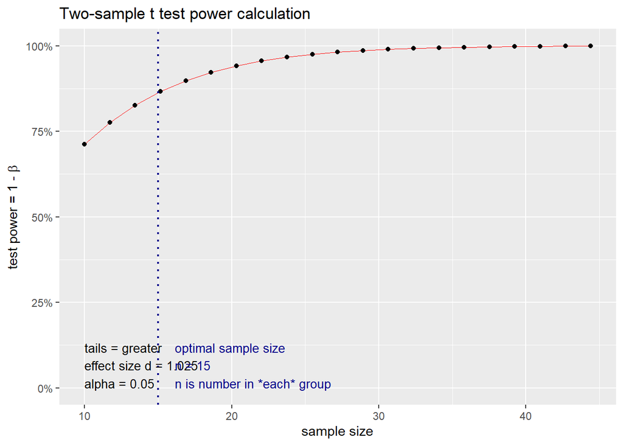

```r
plot(tpower)
```

**n = 15 for each group**

### Possible Recommendations

**Authors (Names and Percentages)**: Ningdan Zhang 100%

For the first question asking whether the non-tipping model increases restaurant profit, if :

1. We do not reject the null hypothesis H0, then we do not have enough evidence that the average profit generated by the non-tipping model is higher than the ones of the conventional-tipping model. As a result, we would recommend Texas Roadhouse stores stay in the current conventional-tipping model to save the expenses required for the changes.
2. We reject H0 and accept alternative hypothesis Ha, then we have enough evidence that the average profit generated by the non-tipping model is higher than the ones of the conventional-tipping model. As a result, we would recommend Texas Roadhouse stores switch from the conventional-tipping model to non-tipping model.

For the second question asking whether the non-tipping model increases customer flow, if :

1. We do not reject the null hypothesis H0, then we do not have enough evidence that the average number of customers has increased compared to the ones of the conventional-tipping model. Thus, we would recommend Texas Roadhouse stores stick with the current conventional-tipping model.
2. We reject null hypothesis H0 and accept alternative hypothesis Ha, then we have enough evidence that the average number of customers has increased compared to the ones of the conventional-tipping model. Thus, we would recommend Texas Roadhouse stores switch from the conventional-tipping model to the non-tipping model.

For the third question asking whether the non-tipping model influences employees’ intention to work, if:

1. We do not reject the null hypothesis H0, then we do not have enough evidence that the mean employees’ rating score from the non-tipping model is different from the ones from the conventional-tipping model. This means that we do not have enough evidence that the non-tipping model influences employees’ intention to work. Thus, we would recommend further observations on employees’ intentions.
2. We reject null hypothesis H0 and accept alternative hypothesis Ha, then we have enough evidence that the mean employees’ rating score from the non-tipping model is different from the ones from the conventional-tipping model. This means that we have enough evidence that the non-tipping model influences employees’ intention to work. Thus, we would recommend conducting further studies to determine how it will affect employees’ intention to work, and decide if to make managerial alterations accordingly.

### Limitations and Uncertainties

**Authors (Names and Percentages)**: Ningdan Zhang 100%

There are, however, several limitations and uncertainties of this research. Firstly, the sample selection process may face potential flaws. When collecting samples for the experiment, we are using cluster sampling on a county scale, followed by simple random selection to choose random stores from the specified clusters. Although cluster sampling should reduce the possibility of people living near more than one Texas Roadhouse becoming confused by the different policies of two adjoining restaurants, there might still be stores very close to each other since they might be located at the borders of two counties. Additionally, to ensure the randomness of the in-cluster sampling, we cannot interfere with these stores if we observe such results, so the flaw potential remains. However, the chance that the stores were located very close to the border was minimal since the store managers would also consider competition and substitution relationships between stores while opening a new store.

Secondly, changing prices on the menu will increase taxes, which might also affect customer behavior. The total prices paid by the customers consist of both the prices and taxes, and the taxes were a fixed rate multiplied by the price on the menu. To apply the non-tipping models, our experiment design has increased the prices on the menu by 18%. If the price of the menu increases, so will the taxes. The taxes will not be reflected in shop income or as an incentive for servers, but will increase consumer costs. As a result, consumers are paying more than they did previously under the non-tipping model, which would most certainly influence their purchasing decisions.

Thirdly, the results of the desire to work survey may not accurately reflect all employees. The worker composition of each Texas Roadhouse store might be slightly different. Some stores may have more part-time employees than other stores. The payroll settlement for full-time workers and part-time workers usually differs, whereas full-time workers receive their paychecks on a monthly basis, while part-time workers receive their paychecks on a daily basis. Under the conventional-tipping model, a shorter payroll settlement period may lead part-time workers to seek direct, faster, cash earnings. As a result, workers will be less enthusiastic about the non-tipping model and are more likely to respond negatively to the survey. If a selected Texas Roadhouse store is experiencing staff shortage in the particular month, they might have hired more part-time workers, making the result less representative for all employees.

Fourthly, the service providers’ intention to work was merely a short-term result and cannot ensure a long-term effect. The experiment was conducted over a one-month period, during which employees were just starting to get familiar with the new non-tipping model. Their thoughts about the non-tipping model might change over time after they are fully familiar. Thus, the survey results can only serve as short-term evidence in the matter of employees’ intention to work. The long-term effect is still ambiguous and needs further study.

Fifthly, since employees work in the same stores, they might have some correlation in their responses to the survey. Employees working within the same Texas Roadhouse store affect each other’s responses in their survey results. Although we can separate them when doing the survey, they might share their thoughts towards the new non-tipping model while working before filling out the survey, making their responses have potential correlations.

## Part 2: Simulation of Effects

**Authors (Names and Percentages)**: Haijin Chen 100%

For the simulation process of the three research questions, a total of 30 sample restaurants would be used, 15 each for the treatment group and the control group. The simulation process of each research question is divided into two scenarios: no effect and an expected effect, which will make our report more specific because it will demonstrate the two expected outcomes of choosing the non-tipping model. In each scenario, the RNORM function would be needed to generate a random dataset, which would assign a random value to all samples in the treatment group and control group. The values are generated based on the estimated mean and standard deviation, and the estimations for these values would be explained in the respective questions that follow. When a complete dataset is available, the statistical test can be performed to determine whether there is sufficient evidence to support our hypothesis by determining the P-value, effect size, and confidence interval. This single simulated experiment is then repeated a thousand times to obtain empirical results about the performance of the statistical methods in these scenarios.

### Research Question 1 : Profit

According to the calculation of sample size in proposal part, the mean profit for a Texas Roadhouse using the conventional-tipping model is approximately $41,000. Population standard deviation would be 4000 based on the estimation by range rule of thumb. Null hypothesis is that average profit generated from non-tipping model is less or equal to average profit generated from conventional-tipping models. Alternative hypothesis is that average profit generated from NT models is greater than that of CT model.

#### Scenario 1: No Effect

When the transition to the non-tipping model has no effect, the mean profit of the restaurant is less than or equal to the mean profit of the conventional-tipping model. $41,000 will be the estimated mean profit of the non-tipping model used to generate the simulation.

```r
n = 30
library(data.table)
library(DT)
set.seed(31)
dat = data.table(Group = c(rep.int(x='Treatment',time=n/2),rep.int(x='Control',times=n/2)))
dat[Group == 'Control',Profit:=round(x=rnorm(n=.N,mean=41000,sd=4000),digits = 1)]
dat[Group == 'Treatment',Profit:=round(x=rnorm(n=.N,mean=41000,sd=4000),digits = 1)]
datatable(data=dat)
```

|  | Group | Profit |
| --- | --- | --- |
| 1 | Treatment | 37329.8 |
| 2 | Treatment | 40813.8 |
| 3 | Treatment | 44425.5 |
| 4 | Treatment | 41133.3 |
| 5 | Treatment | 37309.8 |
| 6 | Treatment | 34416.5 |
| 7 | Treatment | 40193.7 |
| 8 | Treatment | 43479.2 |
| 9 | Treatment | 44035.3 |
| 10 | Treatment | 40524.6 |

[output cut: 20 more lines]

```r
t.test(x=dat[Group=='Treatment',Profit],y=dat[Group=='Control',Profit],mu=0,alternative = 'greater')
```

```
    Welch Two Sample t-test

data:  dat[Group == "Treatment", Profit] and dat[Group == "Control", Profit]
t = 0.21533, df = 27.967, p-value = 0.4155
alternative hypothesis: true difference in means is greater than 0
95 percent confidence interval:
 -2014.978       Inf
sample estimates:
mean of x mean of y
 41165.72  40873.72
```

This is a dataset generated by a single simulation. The mean profit of the NT model is $41165.72, and the mean profit of the CT model is $40873.72. According to the result of the two-sample t test, P-value is 0.4155, which is much greater than the significance level. Null hypothesis cannot be rejected if the experiment generates data like it, and there is a lack of evidence to say that the non-tipping model can generate more profit.

##### 1000 Simulated Studies

```r
library(data.table)
library(DT)

analyze.experiment = function(the.dat){
  require(data.table)
  setDT(the.dat)

  the.test = t.test(x = the.dat[Group == 'Treatment',Profit],y = the.dat[Group == 'Control',Profit], alternative = 'greater')
  the.effect = the.test$estimate[1] - the.test$estimate[2]
  lower.bound = the.test$conf.int[1]
  upper.bound = the.test$conf.int[2]
  p = the.test$p.value

  result = data.table(effect = the.effect,lower_ci = lower.bound,upper_ci = upper.bound, p = p)
  return(result)
}

B = 1000
n = 30
RNGversion(vstr=3.6)
set.seed(31)
Experiment = 1:B
Group=c(rep.int(x='Treatment',times=n/2),rep.int(x='Control',times=n/2))

sim.dat = as.data.table(expand.grid(Experiment = Experiment,Group = Group))
setorderv(x = sim.dat, cols = c('Experiment','Group'), order = c(1,1))
sim.dat[Group == 'Control', Profit:=round(x=rnorm(n=.N,mean=41000,sd=4000),digits=1)]
sim.dat[Group == 'Treatment', Profit:=round(x=rnorm(n=.N,mean=41000,sd=4000),digits=1)]

exp.results = sim.dat[,analyze.experiment(the.dat = .SD), keyby = 'Experiment']
DT::datatable(data=round(x=exp.results[,],digits = 3),rownames=F)
```

| Experiment | effect | lower_ci | upper_ci | p |
| --- | --- | --- | --- | --- |
| 1 | -253.673 | -2619.091 |  | 0.572 |
| 2 | -169.493 | -2709.471 |  | 0.545 |
| 3 | 1563.487 | -1196.353 |  | 0.171 |
| 4 | 1905.733 | -725.206 |  | 0.114 |
| 5 | -677.54 | -2888.623 |  | 0.697 |
| 6 | -1497.487 | -3516.949 |  | 0.891 |
| 7 | -2184.647 | -4763.845 |  | 0.92 |
| 8 | -1289.827 | -4096.376 |  | 0.78 |
| 9 | 72.947 | -2015.59 |  | 0.476 |
| 10 | 1007.087 | -1214.448 |  | 0.224 |

[output cut: 990 more lines]

##### Analysis on Simulation

- Power

```r
exp.results[,mean(p<0.05)]
```

```
[1] 0.06
```

- Range of observed effects

```r
exp.results[,summary(effect)]
```

```
    Min.  1st Qu.   Median     Mean  3rd Qu.     Max.
-5144.63  -886.62    64.12    79.58  1049.47  4682.59
```

- Range of the lower bound of the 95% confidence interval

```r
exp.results[,summary(lower_ci)]
```

```
   Min. 1st Qu.  Median    Mean 3rd Qu.    Max.
  -7692   -3390   -2365   -2383   -1396    2667
```

Repeating this experiment 1000 times with the same simulation procedure, only 60 of them have significant results and 940 times indicate failure to reject the null hypothesis. The mean effect size is $79.58, and it is 95% confident that the interval from -$2,383 to infinite captures the true mean effect.

#### Scenario 2: An Expected Effect

```r
n = 30
library(data.table)
library(DT)
set.seed(31)
dat = data.table(Group = c(rep.int(x='Treatment',time=n/2),rep.int(x='Control',times=n/2)))
dat[Group == 'Control',Profit:=round(x=rnorm(n=.N,mean=41000,sd=4000),digits = 1)]
dat[Group == 'Treatment',Profit:=round(x=rnorm(n=.N,mean=45100,sd=4000),digits = 1)]
datatable(data=dat)
```

|  | Group | Profit |
| --- | --- | --- |
| 1 | Treatment | 41429.8 |
| 2 | Treatment | 44913.8 |
| 3 | Treatment | 48525.5 |
| 4 | Treatment | 45233.3 |
| 5 | Treatment | 41409.8 |
| 6 | Treatment | 38516.5 |
| 7 | Treatment | 44293.7 |
| 8 | Treatment | 47579.2 |
| 9 | Treatment | 48135.3 |
| 10 | Treatment | 44624.6 |

[output cut: 20 more lines]

```r
t.test(x=dat[Group=='Treatment',Profit],y=dat[Group=='Control',Profit],mu=0,alternative = 'greater')
```

```
    Welch Two Sample t-test

data:  dat[Group == "Treatment", Profit] and dat[Group == "Control", Profit]
t = 3.2387, df = 27.967, p-value = 0.001545
alternative hypothesis: true difference in means is greater than 0
95 percent confidence interval:
 2085.022      Inf
sample estimates:
mean of x mean of y
 45265.72  40873.72
```

This is a dataset generated by a single simulation. The mean profit of the NT model is $45,265.72, and the mean profit of the CT model is $40,873.72. According to the result of the two-sample t test, P-value is 0.001545, which is smaller than the significance level. Null hypothesis should be rejected if the experiment generates data like it, and there is enough evidence to say that the non-tipping model can generate more profit.

##### 1000 Simulated Studies

```r
library(data.table)
library(DT)

analyze.experiment = function(the.dat){
  require(data.table)
  setDT(the.dat)
  the.test = t.test(x = the.dat[Group == 'Treatment',Profit],y = the.dat[Group == 'Control',Profit], alternative = 'greater')
  the.effect = the.test$estimate[1] - the.test$estimate[2]
  lower.bound = the.test$conf.int[1]
  upper.bound = the.test$conf.int[2]
  p = the.test$p.value
  result = data.table(effect = the.effect,lower_ci = lower.bound,upper_ci = upper.bound, p = p)
  return(result)
}

B = 1000
n = 30
RNGversion(vstr=3.6)
set.seed(31)
Experiment = 1:B
Group=c(rep.int(x='Treatment',times=n/2),rep.int(x='Control',times=n/2))

sim.dat = as.data.table(expand.grid(Experiment = Experiment,Group = Group))
setorderv(x = sim.dat, cols = c('Experiment','Group'), order = c(1,1))
sim.dat[Group == 'Control', Profit:=round(x=rnorm(n=.N,mean=41000,sd=4000),digits=1)]
sim.dat[Group == 'Treatment', Profit:=round(x=rnorm(n=.N,mean=45100,sd=4000),digits=1)]

exp.results = sim.dat[,analyze.experiment(the.dat = .SD), keyby = 'Experiment']
DT::datatable(data=round(x=exp.results[,],digits = 3),rownames=F)
```

| Experiment | effect | lower_ci | upper_ci | p |
| --- | --- | --- | --- | --- |
| 1 | 3846.327 | 1480.909 |  | 0.005 |
| 2 | 3930.507 | 1390.529 |  | 0.007 |
| 3 | 5663.487 | 2903.647 |  | 0.001 |
| 4 | 6005.733 | 3374.794 |  | 0 |
| 5 | 3422.46 | 1211.377 |  | 0.007 |
| 6 | 2602.513 | 583.051 |  | 0.018 |
| 7 | 1915.353 | -663.845 |  | 0.108 |
| 8 | 2810.173 | 3.624 |  | 0.05 |
| 9 | 4172.947 | 2084.41 |  | 0.001 |
| 10 | 5107.087 | 2885.552 |  | 0 |

[output cut: 990 more lines]

##### Analysis on Simulation

- Power

```r
exp.results[,mean(p<0.05)]
```

```
[1] 0.882
```

- Range of observed effects

```r
exp.results[,summary(effect)]
```

```
   Min. 1st Qu.  Median    Mean 3rd Qu.    Max.
  -1045    3213    4164    4180    5149    8783
```

- Range of the lower bound of the 95% confidence interval

```r
exp.results[,summary(lower_ci)]
```

```
   Min. 1st Qu.  Median    Mean 3rd Qu.    Max.
-3591.7   710.2  1735.2  1717.1  2704.2  6766.9
```

Repeating this experiment 1000 times with the same simulation procedure, 882 times indicate that the difference is significant, and the null hypothesis should be rejected. The mean effect size is $4,180, and it is 95% confident that the interval from $1,717.1 to infinite captures the true mean effect.

### Research Question 2 : Customer Flow

According to Texas Roadhouse’s financial statement for fiscal year 2021, it had total revenues of approximately $3,463,946 for the year. Dividing the revenue by 600 stores and 12 months, and then dividing by the expected per capita spending of $40, our projection formula yields an average of 12,000 customers a month for a Texas Roadhouse restaurant. It is expected that the conventional-tipping model will continue to maintain this average number of customers. We expect a more than 10% customer flow growth rate to be the appropriate effect size, which is about 1,500 customers per month, 50 per day. Applying the range rule of thumb, a population standard deviation of customer flow around 1,500 would be used in this experiment. Null hypothesis is that average customer flow from the non-tipping model is less or equal to average customer flow from conventional-tipping model. Alternative hypothesis is that average customer flow from NT model is greater than that of CT model.

#### Scenario 1: No Effect

When the transition to the non-tipping model has no effect, the mean customer flow of the restaurant is less than or equal to the mean customer flow of the conventional-tipping model. 12,000 customers will be the estimated mean customers of the non-tipping model used to generate the simulation.

```r
n = 30
library(data.table)
library(DT)
set.seed(330)
dat = data.table(Group = c(rep.int(x='Treatment',time=n/2),rep.int(x='Control',times=n/2)))
dat[Group == 'Control',Customer:=round(x=rnorm(n=.N,mean=12000,sd=1500),digits = 0)]
dat[Group == 'Treatment',Customer:=round(x=rnorm(n=.N,mean=12000,sd=1500),digits = 0)]
datatable(data=dat)
```

|  | Group | Customer |
| --- | --- | --- |
| 1 | Treatment | 11630 |
| 2 | Treatment | 13738 |
| 3 | Treatment | 12100 |
| 4 | Treatment | 10427 |
| 5 | Treatment | 11857 |
| 6 | Treatment | 13556 |
| 7 | Treatment | 12182 |
| 8 | Treatment | 11340 |
| 9 | Treatment | 12282 |
| 10 | Treatment | 10558 |

[output cut: 20 more lines]

```r
t.test(x=dat[Group=='Treatment',Customer],y=dat[Group=='Control',Customer],mu=0,alternative = 'greater')
```

```
    Welch Two Sample t-test

data:  dat[Group == "Treatment", Customer] and dat[Group == "Control", Customer]
t = -0.61222, df = 25.756, p-value = 0.7271
alternative hypothesis: true difference in means is greater than 0
95 percent confidence interval:
 -1368.853       Inf
sample estimates:
mean of x mean of y
 11876.40  12237.87
```

This is a dataset generated by a single simulation. The mean customer flow of the NT model is 11,876.40, and the mean customer flow of the CT model is 12,237.87. According to the result of the two-sample t test, P-value is 0.7271, which is much greater than the significance level. Null hypothesis cannot be rejected if the experiment generates data like it, and there is a lack of evidence to say that the non-tipping model can help increase the number of customers.

##### 1000 Simulated Studies

```r
library(data.table)
library(DT)

analyze.experiment = function(the.dat){
  require(data.table)
  setDT(the.dat)

  the.test = t.test(x = the.dat[Group == 'Treatment',Customerflow],y = the.dat[Group == 'Control',Customerflow], alternative = 'greater')
  the.effect = the.test$estimate[1] - the.test$estimate[2]
  lower.bound = the.test$conf.int[1]
  upper.bound = the.test$conf.int[2]
  p = the.test$p.value

  result = data.table(effect = the.effect,lower_ci = lower.bound,upper_ci = upper.bound, p = p)
  return(result)
}

B = 1000
n = 30
RNGversion(vstr=3.6)
set.seed(330)
Experiment = 1:B
Group=c(rep.int(x='Treatment',times=n/2),rep.int(x='Control',times=n/2))

sim.dat = as.data.table(expand.grid(Experiment = Experiment,Group = Group))
setorderv(x = sim.dat, cols = c('Experiment','Group'), order = c(1,1))
sim.dat[Group == 'Control', Customerflow:=round(x=rnorm(n=.N,mean=12000,sd=1500),digits=1)]
sim.dat[Group == 'Treatment', Customerflow:=round(x=rnorm(n=.N,mean=12000,sd=1500),digits=1)]

exp.results = sim.dat[,analyze.experiment(the.dat = .SD), keyby = 'Experiment']
DT::datatable(data=round(x=exp.results[,],digits = 3),rownames=F)
```

| Experiment | effect | lower_ci | upper_ci | p |
| --- | --- | --- | --- | --- |
| 1 | 306.053 | -436.957 |  | 0.244 |
| 2 | -508.373 | -1442.727 |  | 0.82 |
| 3 | 436.993 | -372.828 |  | 0.183 |
| 4 | 150.053 | -713.291 |  | 0.385 |
| 5 | 421.907 | -394.762 |  | 0.193 |
| 6 | 99.34 | -790.346 |  | 0.425 |
| 7 | -196.233 | -1305.349 |  | 0.617 |
| 8 | 311.787 | -594.759 |  | 0.282 |
| 9 | -187.333 | -1442.313 |  | 0.601 |
| 10 | 1133.24 | 268.117 |  | 0.017 |

[output cut: 990 more lines]

##### Analysis on Simulation

- Power

```r
exp.results[,mean(p<0.05)]
```

```
[1] 0.04
```

- Range of observed effects

```r
exp.results[,summary(effect)]
```

```
    Min.  1st Qu.   Median     Mean  3rd Qu.     Max.
-2146.71  -360.25   -28.79   -11.40   350.03  2166.65
```

- Range of the lower bound of the 95% confidence interval

```r
exp.results[,summary(lower_ci)]
```

```
   Min. 1st Qu.  Median    Mean 3rd Qu.    Max.
-3085.8 -1304.6  -936.7  -939.8  -575.3  1313.0
```

Repeating this experiment 1000 times with the same simulation procedure, only 40 of them have significant results and 960 times indicate failure to reject the null hypothesis. The mean effect size is -11.4, and it is 95% confident that the interval from -939.8 to infinite captures the true mean effect.

#### Scenario 2: An Expected Effect

When the transition to the non-tipping model has an expected effect, the mean customer flow of the restaurant is more than the mean customer flow of the conventional-tipping model. 13,500 customers will be the estimated mean customers of the non-tipping model used to generate the simulation.

```r
n = 30
library(data.table)
library(DT)
set.seed(330)
dat = data.table(Group = c(rep.int(x='Treatment',time=n/2),rep.int(x='Control',times=n/2)))
dat[Group == 'Control',Customer:=round(x=rnorm(n=.N,mean=12000,sd=1500),digits = 0)]
dat[Group == 'Treatment',Customer:=round(x=rnorm(n=.N,mean=13500,sd=1500),digits = 0)]
datatable(data=dat)
```

|  | Group | Customer |
| --- | --- | --- |
| 1 | Treatment | 13130 |
| 2 | Treatment | 15238 |
| 3 | Treatment | 13600 |
| 4 | Treatment | 11927 |
| 5 | Treatment | 13357 |
| 6 | Treatment | 15056 |
| 7 | Treatment | 13682 |
| 8 | Treatment | 12840 |
| 9 | Treatment | 13782 |
| 10 | Treatment | 12058 |

[output cut: 20 more lines]

```r
t.test(x=dat[Group=='Treatment',Customer],y=dat[Group=='Control',Customer],mu=0,alternative = 'greater')
```

```
    Welch Two Sample t-test

data:  dat[Group == "Treatment", Customer] and dat[Group == "Control", Customer]
t = 1.9283, df = 25.756, p-value = 0.03245
alternative hypothesis: true difference in means is greater than 0
95 percent confidence interval:
 131.1468      Inf
sample estimates:
mean of x mean of y
 13376.40  12237.87
```

##### 1000 Simulated Studies

```r
library(data.table)
library(DT)

analyze.experiment = function(the.dat){
  require(data.table)
  setDT(the.dat)
  the.test = t.test(x = the.dat[Group == 'Treatment',Customerflow],y = the.dat[Group == 'Control',Customerflow], alternative = 'greater')
  the.effect = the.test$estimate[1] - the.test$estimate[2]
  lower.bound = the.test$conf.int[1]
  upper.bound = the.test$conf.int[2]
  p = the.test$p.value
  result = data.table(effect = the.effect,lower_ci = lower.bound,upper_ci = upper.bound, p = p)
  return(result)
}

B = 1000
n = 30
RNGversion(vstr=3.6)
set.seed(330)
Experiment = 1:B
Group=c(rep.int(x='Treatment',times=n/2),rep.int(x='Control',times=n/2))

sim.dat = as.data.table(expand.grid(Experiment = Experiment,Group = Group))
setorderv(x = sim.dat, cols = c('Experiment','Group'), order = c(1,1))
sim.dat[Group == 'Control', Customerflow:=round(x=rnorm(n=.N,mean=12000,sd=1500),digits=1)]
sim.dat[Group == 'Treatment', Customerflow:=round(x=rnorm(n=.N,mean=13500,sd=1500),digits=1)]

exp.results = sim.dat[,analyze.experiment(the.dat = .SD), keyby = 'Experiment']
DT::datatable(data=round(x=exp.results[,],digits = 3),rownames=F)
```

| Experiment | effect | lower_ci | upper_ci | p |
| --- | --- | --- | --- | --- |
| 1 | 1806.053 | 1063.043 |  | 0 |
| 2 | 991.627 | 57.273 |  | 0.041 |
| 3 | 1936.993 | 1127.172 |  | 0 |
| 4 | 1650.053 | 786.709 |  | 0.001 |
| 5 | 1921.907 | 1105.238 |  | 0 |
| 6 | 1599.34 | 709.654 |  | 0.003 |
| 7 | 1303.767 | 194.651 |  | 0.028 |
| 8 | 1811.787 | 905.241 |  | 0.001 |
| 9 | 1312.667 | 57.687 |  | 0.043 |
| 10 | 2633.24 | 1768.117 |  | 0 |

[output cut: 990 more lines]

##### Analysis on Simulation

- Power

```r
exp.results[,mean(p<0.05)]
```

```
[1] 0.854
```

- Range of observed effects

```r
exp.results[,summary(effect)]
```

```
   Min. 1st Qu.  Median    Mean 3rd Qu.    Max.
 -646.7  1139.7  1471.2  1488.6  1850.0  3666.7
```

- Range of the lower bound of the 95% confidence interval

```r
exp.results[,summary(lower_ci)]
```

```
   Min. 1st Qu.  Median    Mean 3rd Qu.    Max.
-1585.8   195.4   563.3   560.2   924.7  2813.0
```

Repeating this experiment 1000 times with the same simulation procedure, 854 times indicate that the difference is significant, and the null hypothesis should be rejected. The mean effect size is 1488.6, and it is 95% confident that the interval from 560.2 to infinite captures the true mean effect.

### Research Question 3 : Employees’ intention to work

Before conducting the survey, no historical data can be referred to set the mean employees’ intention to work rating of CT model at Texas Roadhouse. Texas Roadhouse is a relaxed and enjoyable occasion, so we set this score at 7.5 on a scale of 1 to 10 which represents a pretty good working atmosphere. At the same time, we expected that this rating may be reduced by 1 in the NT model, because waiters are no longer able to earn more tips for better service and then reduce their intention to work. The population standard deviation is determined at 1.5 according to the range rule of thumb again. Null hypothesis that the average employees’ rating score of intention to work from non-tipping model is equal to average employees’ rating score from conventional-tipping model. Alternative hypothesis is that the average employees’ rating score of intention to work from NT model is different from that of CT model.

#### Scenario 1: No Effect

When the shift to the non-tipping model has no effect, average employees’ rating score of intention to work is equal to the mean rating of the conventional-tipping model. 7.5 points will be the estimated mean employees’ rating score of the non-tipping model used to generate the simulation.

```r
n = 30
library(data.table)
library(DT)
set.seed(331)
dat = data.table(Group = c(rep.int(x='Treatment',time=n/2),rep.int(x='Control',times=n/2)))
dat[Group == 'Control',Intention:=round(x=rnorm(n=.N,mean=7.5,sd=1.5),digits = 1)]
dat[Group == 'Treatment',Intention:=round(x=rnorm(n=.N,mean=7.5,sd=1.5),digits = 1)]
datatable(data=dat)
```

|  | Group | Intention |
| --- | --- | --- |
| 1 | Treatment | 5.2 |
| 2 | Treatment | 7.3 |
| 3 | Treatment | 7.8 |
| 4 | Treatment | 6.3 |
| 5 | Treatment | 6.1 |
| 6 | Treatment | 9 |
| 7 | Treatment | 5 |
| 8 | Treatment | 6.6 |
| 9 | Treatment | 9.4 |
| 10 | Treatment | 7.3 |

[output cut: 20 more lines]

```r
t.test(x=dat[Group=='Treatment',Intention],y=dat[Group=='Control',Intention],mu=0,alternative = 'two.sided')
```

```
    Welch Two Sample t-test

data:  dat[Group == "Treatment", Intention] and dat[Group == "Control", Intention]
t = -0.58075, df = 27.206, p-value = 0.5662
alternative hypothesis: true difference in means is not equal to 0
95 percent confidence interval:
 -1.7220952  0.9620952
sample estimates:
mean of x mean of y
 7.086667  7.466667
```

This is a dataset generated by a single simulation. The mean employees’ rating of the NT model is 7.087, and the mean rating of the CT model is 7.467. According to the result of the two-sample t test, P-value is 0.5662, which is much greater than the significance level. Null hypothesis cannot be rejected if the experiment generated data like it, and there is a lack of evidence to say that the employees’ intention to work of non-tipping model is different from that of conventional-tipping model.

##### 1000 Simulated Studies

```r
library(data.table)
library(DT)

analyze.experiment = function(the.dat){
  require(data.table)
  setDT(the.dat)

  the.test = t.test(x = the.dat[Group == 'Treatment',Intention],y = the.dat[Group == 'Control',Intention], alternative = 'two.sided')
  the.effect = the.test$estimate[1] - the.test$estimate[2]
  lower.bound = the.test$conf.int[1]
  upper.bound = the.test$conf.int[2]
  p = the.test$p.value

  result = data.table(effect = the.effect,lower_ci = lower.bound,upper_ci = upper.bound, p = p)
  return(result)
}

B = 1000
n = 30
RNGversion(vstr=3.6)
set.seed(331)
Experiment = 1:B
Group=c(rep.int(x='Treatment',times=n/2),rep.int(x='Control',times=n/2))

sim.dat = as.data.table(expand.grid(Experiment = Experiment,Group = Group))
setorderv(x = sim.dat, cols = c('Experiment','Group'), order = c(1,1))
sim.dat[Group == 'Control', Intention:=round(x=rnorm(n=.N,mean=7.5,sd=1.5),digits=1)]
sim.dat[Group == 'Treatment', Intention:=round(x=rnorm(n=.N,mean=7.5,sd=1.5),digits=1)]

exp.results = sim.dat[,analyze.experiment(the.dat = .SD), keyby = 'Experiment']
DT::datatable(data=round(x=exp.results[,],digits = 3),rownames=F)
```

| Experiment | effect | lower_ci | upper_ci | p |
| --- | --- | --- | --- | --- |
| 1 | -0.067 | -1.38 | 1.247 | 0.918 |
| 2 | 0.727 | -0.571 | 2.024 | 0.261 |
| 3 | -0.247 | -1.499 | 1.006 | 0.688 |
| 4 | -1.013 | -2.093 | 0.066 | 0.065 |
| 5 | -0.107 | -1.378 | 1.164 | 0.864 |
| 6 | -0.227 | -1.283 | 0.83 | 0.664 |
| 7 | -0.287 | -1.448 | 0.875 | 0.616 |
| 8 | 0.2 | -0.866 | 1.266 | 0.703 |
| 9 | 0.4 | -0.721 | 1.521 | 0.471 |
| 10 | -0.907 | -2.141 | 0.328 | 0.142 |

[output cut: 990 more lines]

##### Analysis on Simulation

- Power

```r
exp.results[,mean(p<0.05)]
```

```
[1] 0.041
```

- Range of observed effects

```r
exp.results[,summary(effect)]
```

```
     Min.   1st Qu.    Median      Mean   3rd Qu.      Max.
-1.786667 -0.348333  0.040000  0.009087  0.353333  1.840000
```

- Range of the lower bound and upper bound of the 95% confidence interval

```r
exp.results[,summary(lower_ci)]
```

```
   Min. 1st Qu.  Median    Mean 3rd Qu.    Max.
-3.1395 -1.4979 -1.0898 -1.1070 -0.7545  0.8094
```

```r
exp.results[,summary(upper_ci)]
```

```
   Min. 1st Qu.  Median    Mean 3rd Qu.    Max.
-0.4406  0.7378  1.1383  1.1251  1.5111  2.8706
```

Repeating this experiment 1000 times with the same simulation procedure, only 41 of them have significant results and 959 times indicate failure to reject the null hypothesis. The mean effect size is 0.0091, and it is 95% confident that the interval from -1.107 to 1.1251 captures the true mean effect.

#### Scenario 2: An Expected Effect

When the shift to the non-tipping model has an expected effect, average employees’ rating score of intention to work is not equal to the mean rating of the conventional-tipping model. 6.5 points will be the estimated mean employees’ rating score of the non-tipping model used to generate the simulation.

```r
n = 30
library(data.table)
library(DT)
set.seed(331)
dat = data.table(Group = c(rep.int(x='Treatment',time=n/2),rep.int(x='Control',times=n/2)))
dat[Group == 'Control',Intention:=round(x=rnorm(n=.N,mean=7.5,sd=1.5),digits = 1)]
dat[Group == 'Treatment',Intention:=round(x=rnorm(n=.N,mean=6.5,sd=1.5),digits = 1)]
datatable(data=dat)
```

|  | Group | Intention |
| --- | --- | --- |
| 1 | Treatment | 4.2 |
| 2 | Treatment | 6.3 |
| 3 | Treatment | 6.8 |
| 4 | Treatment | 5.3 |
| 5 | Treatment | 5.1 |
| 6 | Treatment | 8 |
| 7 | Treatment | 4 |
| 8 | Treatment | 5.6 |
| 9 | Treatment | 8.4 |
| 10 | Treatment | 6.3 |

[output cut: 20 more lines]

```r
t.test(x=dat[Group=='Treatment',Intention],y=dat[Group=='Control',Intention],mu=0,alternative = 'two.sided')
```

```
    Welch Two Sample t-test

data:  dat[Group == "Treatment", Intention] and dat[Group == "Control", Intention]
t = -2.109, df = 27.206, p-value = 0.04428
alternative hypothesis: true difference in means is not equal to 0
95 percent confidence interval:
 -2.72209516 -0.03790484
sample estimates:
mean of x mean of y
 6.086667  7.466667
```

This is a dataset generated by a single simulation. The mean employees’ rating of the NT model is 6.087, and the mean rating of the CT model is 7.467. According to the result of the two-sample t test, P-value is 0.04428, which is lower than the significance level. Null hypothesis should be rejected if the experiment generated data like it, and there is enough evidence to say that the employees’ intention to work of non-tipping model is different from and lower than that of conventional-tipping model.

##### 1000 Simulated Studies

```r
library(data.table)
library(DT)

analyze.experiment = function(the.dat){
  require(data.table)
  setDT(the.dat)
  the.test = t.test(x = the.dat[Group == 'Treatment',Intention],y = the.dat[Group == 'Control',Intention], alternative = 'two.sided')
  the.effect = the.test$estimate[1] - the.test$estimate[2]
  lower.bound = the.test$conf.int[1]
  upper.bound = the.test$conf.int[2]
  p = the.test$p.value
  result = data.table(effect = the.effect,lower_ci = lower.bound,upper_ci = upper.bound, p = p)
  return(result)
}

B = 1000
n = 30
RNGversion(vstr=3.6)
set.seed(331)
Experiment = 1:B
Group=c(rep.int(x='Treatment',times=n/2),rep.int(x='Control',times=n/2))

sim.dat = as.data.table(expand.grid(Experiment = Experiment,Group = Group))
setorderv(x = sim.dat, cols = c('Experiment','Group'), order = c(1,1))
sim.dat[Group == 'Control', Intention:=round(x=rnorm(n=.N,mean=7.5,sd=1),digits=1)]
sim.dat[Group == 'Treatment', Intention:=round(x=rnorm(n=.N,mean=6.5,sd=1),digits=1)]

exp.results = sim.dat[,analyze.experiment(the.dat = .SD), keyby = 'Experiment']
DT::datatable(data=round(x=exp.results[,],digits = 3),rownames=F)
```

| Experiment | effect | lower_ci | upper_ci | p |
| --- | --- | --- | --- | --- |
| 1 | -1.027 | -1.904 | -0.15 | 0.023 |
| 2 | -0.533 | -1.394 | 0.327 | 0.215 |
| 3 | -1.16 | -1.999 | -0.321 | 0.009 |
| 4 | -1.673 | -2.403 | -0.944 | 0 |
| 5 | -1.067 | -1.921 | -0.212 | 0.017 |
| 6 | -1.14 | -1.853 | -0.427 | 0.003 |
| 7 | -1.173 | -1.948 | -0.399 | 0.004 |
| 8 | -0.867 | -1.583 | -0.15 | 0.02 |
| 9 | -0.72 | -1.465 | 0.025 | 0.058 |
| 10 | -1.627 | -2.446 | -0.808 | 0 |

[output cut: 990 more lines]

##### Analysis on Simulation

- Power

```r
exp.results[,mean(p<0.05)]
```

```
[1] 0.742
```

- Range of observed effects

```r
exp.results[,summary(effect)]
```

```
   Min. 1st Qu.  Median    Mean 3rd Qu.    Max.
-2.1867 -1.2333 -0.9733 -0.9943 -0.7600  0.2267
```

- Range of the lower bound and upper bound of the 95% confidence interval

```r
exp.results[,summary(lower_ci)]
```

```
   Min. 1st Qu.  Median    Mean 3rd Qu.    Max.
-3.0841 -1.9987 -1.7316 -1.7388 -1.5047 -0.4599
```

```r
exp.results[,summary(upper_ci)]
```

```
   Min. 1st Qu.  Median    Mean 3rd Qu.    Max.
-1.3063 -0.5081 -0.2432 -0.2498  0.0105  0.9133
```

### Summary Table of Simulation Studies

| Research Question | Scenario | Mean Effect in Simulated Data | 95% Confidence Interval of Mean Effect | Percentage of False Positives | Percentage of True Negatives | Percentage of False Negatives | Percentage of True Positives |
| --- | --- | --- | --- | --- | --- | --- | --- |
| Question 1 | No Effect | 79.58 | [-2383,∞] | 0.06 | 0.94 |  |  |
| Question 1 | Effect:$4,100 | 4180 | [1717.1,∞] |  |  | 0.118 | 0.882 |
| Question 2 | No Effect | -11.4 | [-939.8,∞] | 0.04 | 0.96 |  |  |
| Question 2 | Effect:1,500 | 1488.6 | [560.2,∞] |  |  | 0.146 | 0.854 |
| Question 3 | No Effect | 0.009 | [-1.107,1.125] | 0.041 | 0.959 |  |  |
| Question 3 | Effect:-1 | -0.994 | [-1.739,-0.250] |  |  | 0.258 | 0.742 |

### References

Clifton, S. M., Herbers, E., Chen, J., & Abrams, D. M. (2018). The tipping point: A mathematical model for the profit-driven abandonment of restaurant tipping. AIP Publishing. Retrieved from https://aip.scitation.org/doi/10.1063/1.5004711

Lynn, M. (2017). Should U.S. restaurants abandon tipping? A review of the issues and evidence. Psychosociological Issues in Human Resource Management, 5(1), 120. https://doi.org/10.22381/pihrm5120174

Ross, J., & Welsh, J. (2020). Understanding the ‘tipped minimum wage’: Critical directions for US policy research. Social Policy and Society, 20(2), 192–210. https://doi.org/10.1017/s1474746420000214

Texas Roadhouse, Inc. (2022). 10-K Annual Report. SEC Filings. Retrieved from https://investor.texasroadhouse.com/financial-info/sec-filings/default.aspx